# Stats 506 F20, Group Project

ARIMA Model Tutorial

Group 3: Zhilin He, Jialun Li, Chuwen Li

November 12, 2020

## Introduction

### General

Time series data can be modeled in a variety of ways. Autoregressive integrated moving average (ARIMA) model is a common type of model used for time series data.

A general ARIMA model consists of three parts: the “AR” part means the variable of interest is regressed on its lag terms, the “I” part means the differenced values are used, and the “MA” part means the regression error is modelled as a linear combination of error terms in the past. The purpose of using differenced terms is to make the time series stationary for autoregression.

ARIMA models are fitted in order to understand the data better and forecast future data. They are based on linear regression models. The best model can be chosen using AIC or BIC.

### Mathematical Model

Given a time series $\{X_t\}$, an $ARIMA(p, d, q)$ model can be expressed as:
$$(1-\sum_{i=1}^p\phi_iL^i)(1-L)^dX_t=
(1+\sum_{i=1}^q\theta_iL^i)\epsilon_t + \delta$$
where $\epsilon_t$ is the error term, $L$ is the lag operator, i.e. $LX_t = X_{t-1}, \forall t>1$, $p$ is the number of lagged terms of $X$, $d$ is the number of times of differencing needed for stationarity, $q$ is the number of lagged forecast errors in prediction, $\delta$ is the interception term for the regression, and $\theta, \phi$’s are the estimated regression coefficients.

## Data Description

We use the [nifty fifty stocks data] (https://www.kaggle.com/rohanrao/nifty50-stock-market-data) from NSE India as an example in this tutorial.

The data contains daily open, close, highest and lowest prices, volume and other relevant information for the “Nifty Fifty” stocks since January 2000. There are 50 stocks, 15 variables and 230104 observations in total. Detailed variable descriptions are shown in Table 1 below.

| Variables Name | Variable Description |
| --- | --- |
| Date | Date |
| Symbol | Symbol of the stock (name, identifier) |
| Series | Type of security (“EQ” for all rows) |
| Prev Close | Previous day’s close price |
| Open | Open price of day |
| High | Highest price in day |
| Low | Lowest price in day |
| Last | Last traded price in day |
| Close | Close price of day |
| VWAP | Volume Weighted Average Price |
| Volume | Volume |
| Turnover | Turnover |
| Trades | Number of Trades (Half missing) |
| Deliverable Volume | Amount of deliverable volume (7% missing) |
| %Deliverable | Percent of deliverable volume (7% missing) |

**Table 1**. Variables in the dataset

As we are more interested in the stock prices, we use the variable `VWAP` for the most part. It can summarize the average price of the stock on a trading day. We want to catch the trend of stock prices across the years and possibly forecast future stock prices.

## Core Example

### Python

#### Data cleaning and visualization

Firstly, we import the data.

```python
import sys
sys.path.append('/usr/local/lib/python3.8/site-packages')
import pandas as pd
import numpy as np
df = pd.read_csv('./NIFTY50_all.csv')
```

The variable `Trades` has too many missing values, we can delete it. We can delete redundant variables and impute `%Deliverable` via Simple Imputation because the are not so many missing values. We also need to merge different symbols for the same stock.

```python
from datetime import datetime
from sklearn.impute import SimpleImputer
# Drop redundant variables and variables with too many missing values
df['Date'] = [datetime.strptime(x, '%Y-%m-%d') for x in df['Date']]
df1 = df.drop(['Trades', 'Deliverable Volume', 'Series'], axis=1)
ls1 = ['MUNDRAPORT', 'UTIBANK', 'BAJAUTOFIN', 'BHARTI', 'HEROHONDA',
       'HINDALC0', 'HINDLEVER', 'INFOSYSTCH', 'JSWSTL', 'KOTAKMAH', 'TELCO',
       'TISCO', 'UNIPHOS', 'SESAGOA', 'SSLT', 'ZEETELE']
ls2 = ['ADANIPORTS', 'AXISBANK', 'BAJFINANCE', 'BHARTIARTL', 'HEROMOTOCO',
       'HINDALCO', 'HINDUNILVR', 'INFY', 'JSWSTEEL', 'KOTAKBANK', 'TATAMOTORS',
       'TATASTEEL', 'UPL', 'VEDL', 'VEDL', 'ZEEL']
df1['Symbol'] = df1['Symbol'].replace(ls1, ls2)
df1['Symbol'] = pd.Categorical(df1['Symbol'])
# Impute missing values
df2 = pd.get_dummies(data=df1, drop_first=True)
df2['Date']=df2['Date'].map(datetime.toordinal)
imp = SimpleImputer()
p = imp.fit_transform(df2)
df1['%Deliverble'] = p[:, 10]
```

We can take a look at the data. Take the stock “ADANIPORTS” as an example.

```python
import matplotlib.pyplot as plt
names = df1['Symbol'].cat.categories
example = df1[df1['Symbol'] == names[0]]
fig, ax = plt.subplots(3, 1, figsize=(8, 8))
ax[0].plot(example['Date'], example['VWAP'])
ax[0].set_xticks([])
```

```
## []
```

```python
ax[0].set_xlabel('Days')
ax[0].set_ylabel('Volume weighted average price')
ax[1].plot(example['Date'], example['Volume'])
ax[1].set_xticks([])
```

```
## []
```

```python
ax[1].set_xlabel('Days')
ax[1].set_ylabel('Volume')
ax[2].plot(example['Date'], example['Turnover'])
ax[2].set_xticks([])
```

```
## []
```

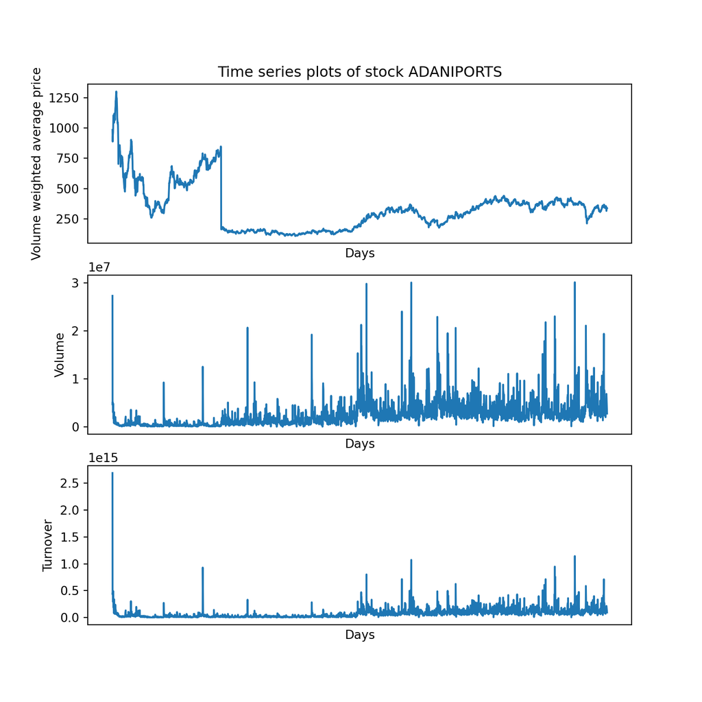

```python
ax[2].set_xlabel('Days')
ax[2].set_ylabel('Turnover')
ax[0].set_title('Time series plots of stock %s' % names[0])
```

#### Determine model parameters

We will use the time series VWAP for the analysis below.

The differencing parameter $d$ of the model can be determined by doing Augmented Dickey-Fuller tests, which can indicate whether the time series are stationary.

```python
from statsmodels.tsa.arima_model import ARIMA
from pmdarima.arima.utils import ndiffs
# This function chooses the smallest d for the series to be stationary
names = df1['Symbol'].cat.categories
ls0 = []
for i in names:
    subdf = df1[df1['Symbol'] == i]
    # Select the rows for stock i
    ls0.append(ndiffs(subdf['VWAP'], test='adf'))
ls0  # Most values are 1
```

```
## [0, 1, 1, 0, 1, 0, 1, 1, 1, 1, 1, 1, 1, 1, 1, 0, 1, 1, 1, 1, 0, 1, 1, 1, 0, 1, 1, 1, 1, 0, 1, 1, 1, 1, 1, 1, 1, 1, 1, 0, 1, 1, 1, 1, 1, 1, 1, 1, 0, 0]
```

```python
max(ls0) # We don't need 2-order differencing
```

```
## 1
```

In order to ensure all time series are stationary, we choose $d=1$ for all stocks.

The AR parameter $p$ of the model can be determined by looking at Partial Autocorrelation plots. These plots indicate the correlation between the series and its lag. We use the first 4 stocks alphabetically as a sample. Notice the series need to be differenced first ($d=1$).

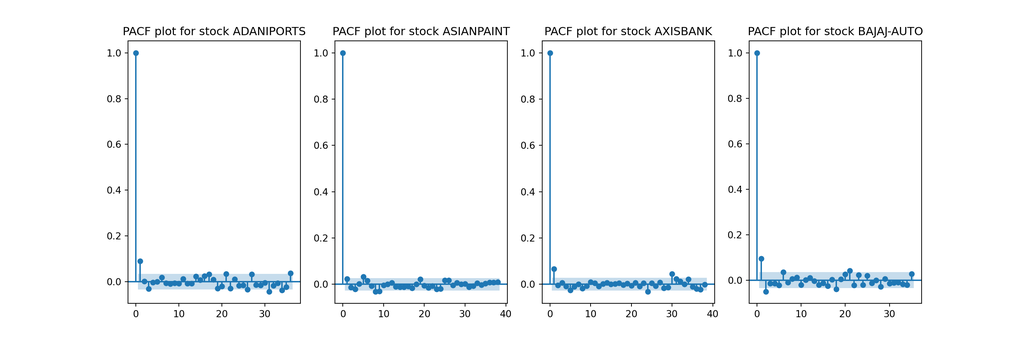

```python
from statsmodels.graphics.tsaplots import plot_acf, plot_pacf
fig, ax = plt.subplots(1, 4, figsize=(15, 5))
# Take the first 4 stocks as a sample
for i in range(4):
    subdf = df1[df1['Symbol'] == names[i]]
    # Select the rows for stock number i
    plot_pacf(subdf['VWAP'].diff().dropna(), ax=ax[i])
    ax[i].set_title('PACF plot for stock %s' % names[i])
```

Notice lag 1 is at least borderline significant in the plots for all stocks, but lag 2 is not significant. Therefore, we can choose $p=1$ for all stocks.

The MA parameter $q$ of the model can be determined by looking at Autocorrelation (ACF) plots. We use the next 4 stocks alphabetically as a sample. Similarly, the series need to be differenced ($d=1$).

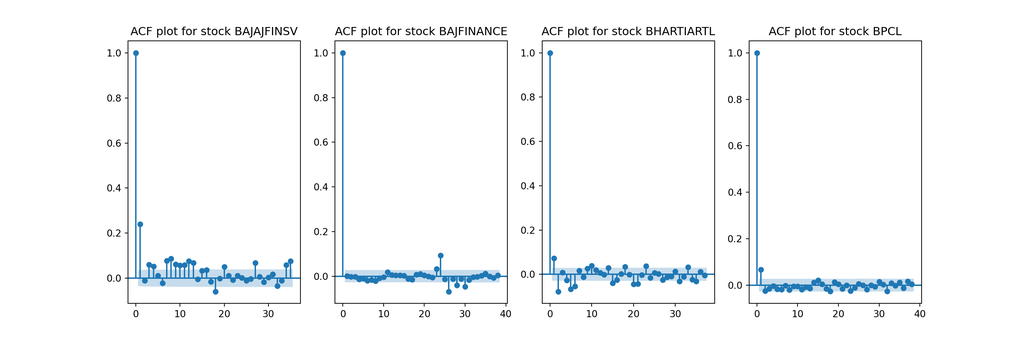

```python
fig, ax = plt.subplots(1, 4, figsize=(15, 5))
for i in range(4):
    subdf = df1[df1['Symbol'] == names[i+4]]
    plot_acf(subdf['VWAP'].diff().dropna(), ax=ax[i])
    ax[i].set_title('ACF plot for stock %s' % names[i+4])
```

Notice lag 1 is significant for most of the stocks but lag 2 is not. Therefore we can choose $q=1$ for the MA term.

#### Fit models

According to the process above, we choose the $ARIMA(1, 1, 1)$ for all stocks. After fitting the models, we can view some of the summaries. Take the first 5 stocks alphabetically as an example.

```python
mlist = [] # Models
flist = [] # Model fits
for i in names:
    subdf = df1[df1['Symbol'] == i]
    m = ARIMA(list(subdf['VWAP']), order=(1, 1, 1))
    mlist.append(m)
    flist.append(m.fit(disp=0))
for i in range(5):
    print(flist[i].summary())
```

```
##                              ARIMA Model Results
## ==============================================================================
## Dep. Variable:                    D.y   No. Observations:                 3178
## Model:                 ARIMA(1, 1, 1)   Log Likelihood              -13340.537
## Method:                       css-mle   S.D. of innovations             16.100
## Date:                Thu, 12 Nov 2020   AIC                          26689.074
## Time:                        18:06:05   BIC                          26713.330
## Sample:                             1   HQIC                         26697.773
##
## ==============================================================================
##                  coef    std err          z      P>|z|      [0.025      0.975]
## ------------------------------------------------------------------------------
## const         -0.2048      0.314     -0.652      0.514      -0.820       0.411
## ar.L1.D.y      0.1049      0.151      0.694      0.488      -0.192       0.401
## ma.L1.D.y     -0.0156      0.152     -0.103      0.918      -0.313       0.282
##                                     Roots
## =============================================================================
##                   Real          Imaginary           Modulus         Frequency
## -----------------------------------------------------------------------------
## AR.1            9.5325           +0.0000j            9.5325            0.0000
## MA.1           64.1530           +0.0000j           64.1530            0.0000
## -----------------------------------------------------------------------------
##                              ARIMA Model Results
## ==============================================================================
## Dep. Variable:                    D.y   No. Observations:                 5162
## Model:                 ARIMA(1, 1, 1)   Log Likelihood              -29071.318
## Method:                       css-mle   S.D. of innovations             67.549
## Date:                Thu, 12 Nov 2020   AIC                          58150.637
## Time:                        18:06:05   BIC                          58176.833
## Sample:                             1   HQIC                         58159.803
##
## ==============================================================================
##                  coef    std err          z      P>|z|      [0.025      0.975]
## ------------------------------------------------------------------------------
## const          0.3108      0.960      0.324      0.746      -1.570       2.192
## ar.L1.D.y     -0.1743      0.368     -0.473      0.636      -0.896       0.547
## ma.L1.D.y      0.1985      0.366      0.542      0.588      -0.519       0.916
##                                     Roots
## =============================================================================
##                   Real          Imaginary           Modulus         Frequency
```

[output cut: 55 more lines]

```
## Sample:                             1   HQIC                         34452.196
##
## ==============================================================================
##                  coef    std err          z      P>|z|      [0.025      0.975]
## ------------------------------------------------------------------------------
## const          1.7395      1.497      1.162      0.245      -1.195       4.674
## ar.L1.D.y     -0.1671      0.071     -2.350      0.019      -0.307      -0.028
## ma.L1.D.y      0.4298      0.066      6.537      0.000       0.301       0.559
##                                     Roots
## =============================================================================
##                   Real          Imaginary           Modulus         Frequency
## -----------------------------------------------------------------------------
## AR.1           -5.9832           +0.0000j            5.9832            0.5000
## MA.1           -2.3266           +0.0000j            2.3266            0.5000
## -----------------------------------------------------------------------------
```

Notice that for the first 3 stocks, the model fit is not good. We can consider removing the MA term since it’s non-significant for some stocks, i.e. choosing the $ARIMA(1, 1, 0)$ model.

```python
mlist0 = [] # Models
flist0 = [] # Model fits
for i in names:
    subdf = df1[df1['Symbol'] == i]
    m = ARIMA(list(subdf['VWAP']), order=(1, 1, 0))
    mlist0.append(m)
    flist0.append(m.fit(disp=0))
```

We use AIC has the model choosing criteria. The AIC decreases for the first three stocks, and increases for the 4th and 5th, indicating different stocks need different models.

```python
includema = [] # Whether MA term should be included
for i in range(50):
    includema.append(flist0[i].aic > flist[i].aic)
pd.value_counts(includema)
```

```
## True     28
## False    22
## dtype: int64
```

#### Model diagnostics

Firstly, we can use the in-sample lagged values to predict the time series.

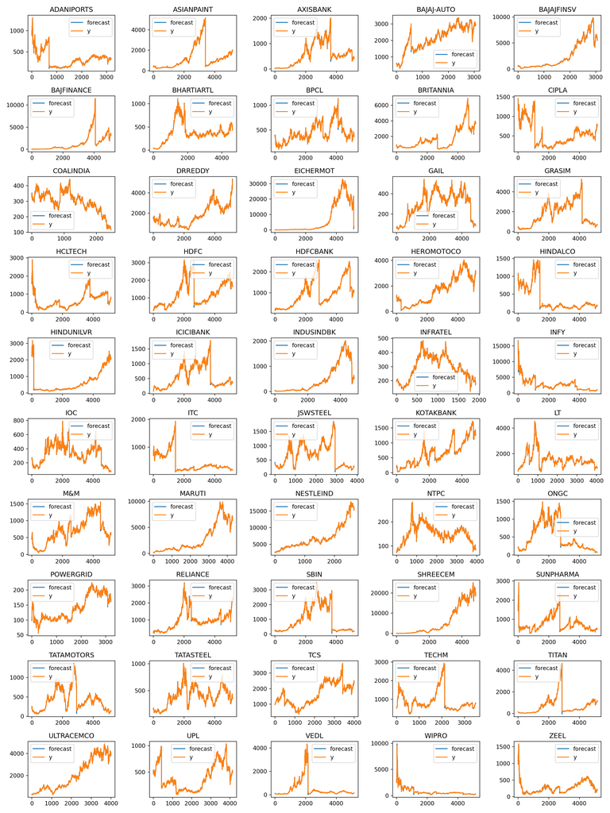

```python
fig, ax = plt.subplots(10, 5, figsize=(15, 20))
for i in range(50):
    if(includema): # ARIMA(1,1,1)
        flist[i].plot_predict(dynamic=False, ax=ax[i // 5, i % 5])
    else: # ARIMA(1,1,0)
        flist0[i].plot_predict(dynamic=False, ax=ax[i // 5, i % 5])
    ax[i // 5, i % 5].set_title(names[i])
fig.tight_layout()
fig
```

We can also forecast future VWAPs using the chosen models. For example, we can forecast the average prices in the next 200 trading days after the time series.

```python
fig, ax = plt.subplots(10, 5, figsize=(15, 20))
for i in range(50):
    if(includema):
        forecast, b, ci = flist[i].forecast(200, alpha=0.05)
    else:
        forecast, b, ci = flist0[i].forecast(200, alpha=0.05)
    subdf = df1[df1['Symbol'] == names[i]]
    ax[i // 5, i % 5].plot(list(subdf['VWAP']))
    idx = range(len(subdf['VWAP']), 200+len(subdf['VWAP']))
    ax[i // 5, i % 5].plot(idx, forecast)
    ax[i // 5, i % 5].fill_between(idx, ci[:, 0], ci[:, 1],
                 alpha=0.15)
    ax[i // 5, i % 5].set_title(names[i])
    ax[i // 5, i % 5].set_xticks([])
```

```python
fig.tight_layout()
```

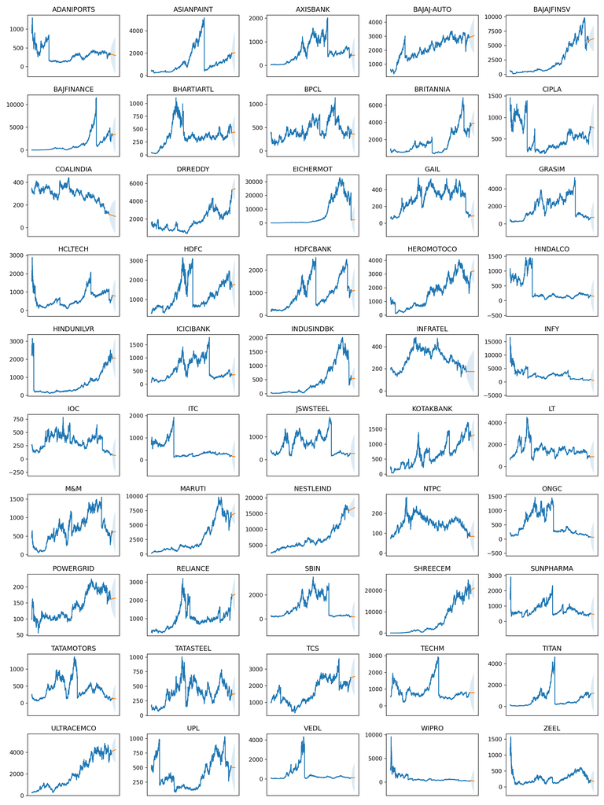

```python
fig
```

Notice the confidence intervals are very wide, indicating it’s not easy to forecast stock prices.

#### Model improvement

Now that we chose different models for different stocks, we can further improve the models by choosing the most proper model for each stock.

We can use `auto_arima` to choose models. It compares different models and chooses the best one. Again, we use ADF test to determine $d$, and AIC to determine $p,q$. Take “ADANIPORTS”, “ASIANPAINT” and “BPCL” as examples.

```python
import pmdarima as paim
subdf = df1[df1['Symbol'] == names[0]]
m1 = paim.auto_arima(subdf['VWAP'], start_p=1, start_q=1, test='adf',
                     max_p=3, max_q=3)
m1.summary() # The chosen model was ARIMA(1, 0, 1), which is a good fit.
```

```
## <class 'statsmodels.iolib.summary.Summary'>
## """
##                                SARIMAX Results
## ==============================================================================
## Dep. Variable:                      y   No. Observations:                 3179
## Model:               SARIMAX(1, 0, 1)   Log Likelihood              -13346.144
## Date:                Thu, 12 Nov 2020   AIC                          26700.287
## Time:                        18:06:25   BIC                          26724.545
## Sample:                             0   HQIC                         26708.987
##                                - 3179
## Covariance Type:                  opg
## ==============================================================================
##                  coef    std err          z      P>|z|      [0.025      0.975]
## ------------------------------------------------------------------------------
## intercept      1.1366      1.144      0.993      0.321      -1.106       3.379
## ar.L1          0.9971      0.002    572.414      0.000       0.994       1.001
## ma.L1          0.0892      0.005     16.587      0.000       0.079       0.100
## sigma2       259.0152      0.418    619.397      0.000     258.196     259.835
## ===================================================================================
## Ljung-Box (Q):                       52.63   Jarque-Bera (JB):         120511061.15
## Prob(Q):                              0.09   Prob(JB):                         0.00
## Heteroskedasticity (H):               0.06   Skew:                           -22.97
## Prob(H) (two-sided):                  0.00   Kurtosis:                       955.73
## ===================================================================================
##
## Warnings:
## [1] Covariance matrix calculated using the outer product of gradients (complex-step).
## """
```

```python
ls0[0] # Indeed, differencing is not needed for the stock 'ADANIPORTS'.
```

```
## 0
```

```python
subdf = df1[df1['Symbol'] == names[1]]
m2 = paim.auto_arima(subdf['VWAP'], start_p=1, start_q=1, test='adf',
                     max_p=3, max_q=3)
m2.summary() # The chosen model was ARIMA(0, 1, 0), which is a good fit.
# For 'ASIANPAINT', the 1-order difference series is close to a constant.
```

```
## <class 'statsmodels.iolib.summary.Summary'>
## """
##                                SARIMAX Results
## ==============================================================================
## Dep. Variable:                      y   No. Observations:                 5163
## Model:               SARIMAX(0, 1, 0)   Log Likelihood              -29072.936
## Date:                Thu, 12 Nov 2020   AIC                          58147.873
## Time:                        18:06:26   BIC                          58154.422
## Sample:                             0   HQIC                         58150.164
##                                - 5163
## Covariance Type:                  opg
## ==============================================================================
##                  coef    std err          z      P>|z|      [0.025      0.975]
## ------------------------------------------------------------------------------
## sigma2      4564.8605      1.982   2303.040      0.000    4560.976    4568.745
## ===================================================================================
## Ljung-Box (Q):                       42.98   Jarque-Bera (JB):        3632346684.27
## Prob(Q):                              0.34   Prob(JB):                         0.00
## Heteroskedasticity (H):               4.65   Skew:                           -60.55
## Prob(H) (two-sided):                  0.00   Kurtosis:                      4110.73
## ===================================================================================
##
## Warnings:
## [1] Covariance matrix calculated using the outer product of gradients (complex-step).
## """
```

```python
subdf = df1[df1['Symbol'] == names[7]]
m3 = paim.auto_arima(subdf['VWAP'], start_p=1, start_q=1, test='adf',
                     max_p=3, max_q=3, error_action='ignore')
m3.summary() # The chosen model was ARIMA(1, 1, 2), which is a good fit.
# For 'BPCL' second order MA term is needed.
```

```
## <class 'statsmodels.iolib.summary.Summary'>
## """
##                                SARIMAX Results
## ==============================================================================
## Dep. Variable:                      y   No. Observations:                 5163
## Model:               SARIMAX(1, 1, 2)   Log Likelihood              -21047.069
## Date:                Thu, 12 Nov 2020   AIC                          42102.139
## Time:                        18:06:44   BIC                          42128.335
## Sample:                             0   HQIC                         42111.305
##                                - 5163
## Covariance Type:                  opg
## ==============================================================================
##                  coef    std err          z      P>|z|      [0.025      0.975]
## ------------------------------------------------------------------------------
## ar.L1          0.9703      0.019     51.948      0.000       0.934       1.007
## ma.L1         -0.9021      0.020    -45.739      0.000      -0.941      -0.863
## ma.L2         -0.0779      0.008    -10.104      0.000      -0.093      -0.063
## sigma2       203.7130      0.511    398.595      0.000     202.711     204.715
## ===================================================================================
## Ljung-Box (Q):                       31.14   Jarque-Bera (JB):          97447842.12
## Prob(Q):                              0.84   Prob(JB):                         0.00
## Heteroskedasticity (H):               5.01   Skew:                           -18.28
## Prob(H) (two-sided):                  0.00   Kurtosis:                       675.11
## ===================================================================================
##
## Warnings:
## [1] Covariance matrix calculated using the outer product of gradients (complex-step).
## """
```

We can improve each of the models invidivually for slightly better forecast performance.

## To-do list

## Outline

## References

1. A modern Time Series tutorial: [Link](https://www.kaggle.com/rohanrao/a-modern-time-series-tutorial)
2. ARIMA model in Wikipedia: [Link](https://en.wikipedia.org/wiki/Autoregressive_integrated_moving_average)